# R Notebook

1 MVP

### You are given a set of data on housing sale prices for the last few years in King County (near Seattle) between May 2014 and May 2015.

### We want you to build an **explanatory model for the price of housing** in King County, i.e. an interpretable model in which the included variables are statistically justifiable.

The variable definitions are:

id - Unique ID for each home sold date - Date of the home sale price - Price of each home sold bedrooms - Number of bedrooms bathrooms - Number of bathrooms, where .5 accounts for a room with a toilet but no shower sqft_living - Square footage of the apartments interior living space sqft_lot - Square footage of the land space floors - Number of floors waterfront - A dummy variable for whether the apartment was overlooking the waterfront or not view - An index from 0 to 4 of how good the view of the property was condition - An index from 1 to 5 on the condition of the apartment grade - An index from 1 to 13, where 1-3 falls short of building construction and design, 7 has an average level of construction and design, and 11-13 have a high quality level of construction and design sqft_above - The square footage of the interior housing space that is above ground level sqft_basement - The square footage of the interior housing space that is below ground level yr_built - The year the house was initially built yr_renovated - The year of the house’s last renovation zipcode - What zipcode area the house is in lat - Lattitude long - Longitude sqft_living15 - The square footage of interior housing living space for the nearest 15 neighbors sqft_lot15 - The square footage of the land lots of the nearest 15 neighbors

```r
library(modelr)
```

```r
houses <- read_csv("data/kc_house_data.csv")
glimpse(houses)
```

```
Rows: 21,613
Columns: 21
$ id            <chr> "7129300520", "6414100192", "5631500400", "2487200875", "1954400510", "7237550310", "132140006…
$ date          <dttm> 2014-10-13, 2014-12-09, 2015-02-25, 2014-12-09, 2015-02-18, 2014-05-12, 2014-06-27, 2015-01-1…
$ price         <dbl> 221900, 538000, 180000, 604000, 510000, 1225000, 257500, 291850, 229500, 323000, 662500, 46800…
$ bedrooms      <dbl> 3, 3, 2, 4, 3, 4, 3, 3, 3, 3, 3, 2, 3, 3, 5, 4, 3, 4, 2, 3, 4, 3, 5, 2, 3, 3, 3, 3, 3, 4, 3, 2…
$ bathrooms     <dbl> 1.00, 2.25, 1.00, 3.00, 2.00, 4.50, 2.25, 1.50, 1.00, 2.50, 2.50, 1.00, 1.00, 1.75, 2.00, 3.00…
$ sqft_living   <dbl> 1180, 2570, 770, 1960, 1680, 5420, 1715, 1060, 1780, 1890, 3560, 1160, 1430, 1370, 1810, 2950,…
$ sqft_lot      <dbl> 5650, 7242, 10000, 5000, 8080, 101930, 6819, 9711, 7470, 6560, 9796, 6000, 19901, 9680, 4850, …
$ floors        <dbl> 1.0, 2.0, 1.0, 1.0, 1.0, 1.0, 2.0, 1.0, 1.0, 2.0, 1.0, 1.0, 1.5, 1.0, 1.5, 2.0, 2.0, 1.5, 1.0,…
$ waterfront    <dbl> 0, 0, 0, 0, 0, 0, 0, 0, 0, 0, 0, 0, 0, 0, 0, 0, 0, 0, 0, 0, 0, 0, 0, 0, 0, 0, 0, 0, 0, 0, 0, 0…
$ view          <dbl> 0, 0, 0, 0, 0, 0, 0, 0, 0, 0, 0, 0, 0, 0, 0, 3, 0, 0, 0, 0, 0, 4, 0, 0, 0, 0, 0, 0, 0, 0, 0, 0…
$ condition     <dbl> 3, 3, 3, 5, 3, 3, 3, 3, 3, 3, 3, 4, 4, 4, 3, 3, 3, 4, 4, 4, 4, 3, 3, 3, 4, 5, 3, 5, 3, 3, 3, 3…
$ grade         <dbl> 7, 7, 6, 7, 8, 11, 7, 7, 7, 7, 8, 7, 7, 7, 7, 9, 7, 7, 7, 7, 7, 9, 8, 7, 8, 6, 8, 8, 7, 8, 8, …
$ sqft_above    <dbl> 1180, 2170, 770, 1050, 1680, 3890, 1715, 1060, 1050, 1890, 1860, 860, 1430, 1370, 1810, 1980, …
$ sqft_basement <dbl> 0, 400, 0, 910, 0, 1530, 0, 0, 730, 0, 1700, 300, 0, 0, 0, 970, 0, 0, 0, 0, 760, 720, 0, 0, 0,…
$ yr_built      <dbl> 1955, 1951, 1933, 1965, 1987, 2001, 1995, 1963, 1960, 2003, 1965, 1942, 1927, 1977, 1900, 1979…
$ yr_renovated  <dbl> 0, 1991, 0, 0, 0, 0, 0, 0, 0, 0, 0, 0, 0, 0, 0, 0, 0, 0, 0, 0, 0, 0, 0, 0, 0, 0, 0, 0, 0, 0, 0…
$ zipcode       <dbl> 98178, 98125, 98028, 98136, 98074, 98053, 98003, 98198, 98146, 98038, 98007, 98115, 98028, 980…
$ lat           <dbl> 47.5112, 47.7210, 47.7379, 47.5208, 47.6168, 47.6561, 47.3097, 47.4095, 47.5123, 47.3684, 47.6…
$ long          <dbl> -122.257, -122.319, -122.233, -122.393, -122.045, -122.005, -122.327, -122.315, -122.337, -122…
$ sqft_living15 <dbl> 1340, 1690, 2720, 1360, 1800, 4760, 2238, 1650, 1780, 2390, 2210, 1330, 1780, 1370, 1360, 2140…
$ sqft_lot15    <dbl> 5650, 7639, 8062, 5000, 7503, 101930, 6819, 9711, 8113, 7570, 8925, 6000, 12697, 10208, 4850, …
```

### Tidy up the data ready for regression:

### You might like to think about removing some or all of date, id, sqft_living15, sqft_lot15 and zipcode (lat and long provide a better measure of location in any event).

### Have a think about how to treat waterfront. Should we convert its type?

#### I think it already behaves like a dummy, and it is numerical, no need to transform it.. But I have to transform it in order to be able to run ggpairs(), split the data set into two (numerical and logical) so I don’t run out of memory ### We converted yr_renovated into a renovated logical variable, indicating whether the property had ever been renovated. You may wish to do the same. ### Have a think about how to treat condition and grade? Are they interval or categorical ordinal data types? #### both condition and grade are categorical ordinal variables, I should dummy them to transform them into numerical variables, but frankly, lm() does it for me.. #### For simplification, I transformed grade into three supersets (3 ordinal categories - low/average/high)

```r
glimpse(houses_tidy)
```

```
Rows: 21,613
Columns: 16
$ price         <dbl> 221900, 538000, 180000, 604000, 510000, 1225000, 257500, 291850, 229500, 323000, 662500, 4680…
$ bedrooms      <dbl> 3, 3, 2, 4, 3, 4, 3, 3, 3, 3, 3, 2, 3, 3, 5, 4, 3, 4, 2, 3, 4, 3, 5, 2, 3, 3, 3, 3, 3, 4, 3, …
$ bathrooms     <dbl> 1.00, 2.25, 1.00, 3.00, 2.00, 4.50, 2.25, 1.50, 1.00, 2.50, 2.50, 1.00, 1.00, 1.75, 2.00, 3.0…
$ sqft_living   <dbl> 1180, 2570, 770, 1960, 1680, 5420, 1715, 1060, 1780, 1890, 3560, 1160, 1430, 1370, 1810, 2950…
$ sqft_lot      <dbl> 5650, 7242, 10000, 5000, 8080, 101930, 6819, 9711, 7470, 6560, 9796, 6000, 19901, 9680, 4850,…
$ floors        <dbl> 1.0, 2.0, 1.0, 1.0, 1.0, 1.0, 2.0, 1.0, 1.0, 2.0, 1.0, 1.0, 1.5, 1.0, 1.5, 2.0, 2.0, 1.5, 1.0…
$ waterfront    <lgl> FALSE, FALSE, FALSE, FALSE, FALSE, FALSE, FALSE, FALSE, FALSE, FALSE, FALSE, FALSE, FALSE, FA…
$ view          <dbl> 0, 0, 0, 0, 0, 0, 0, 0, 0, 0, 0, 0, 0, 0, 0, 3, 0, 0, 0, 0, 0, 4, 0, 0, 0, 0, 0, 0, 0, 0, 0, …
$ condition     <fct> 3, 3, 3, 5, 3, 3, 3, 3, 3, 3, 3, 4, 4, 4, 3, 3, 3, 4, 4, 4, 4, 3, 3, 3, 4, 5, 3, 5, 3, 3, 3, …
$ grade         <fct> average, average, average, average, average, high, average, average, average, average, averag…
$ sqft_above    <dbl> 1180, 2170, 770, 1050, 1680, 3890, 1715, 1060, 1050, 1890, 1860, 860, 1430, 1370, 1810, 1980,…
$ sqft_basement <dbl> 0, 400, 0, 910, 0, 1530, 0, 0, 730, 0, 1700, 300, 0, 0, 0, 970, 0, 0, 0, 0, 760, 720, 0, 0, 0…
$ yr_built      <dbl> 1955, 1951, 1933, 1965, 1987, 2001, 1995, 1963, 1960, 2003, 1965, 1942, 1927, 1977, 1900, 197…
$ lat           <dbl> 47.5112, 47.7210, 47.7379, 47.5208, 47.6168, 47.6561, 47.3097, 47.4095, 47.5123, 47.3684, 47.…
$ long          <dbl> -122.257, -122.319, -122.233, -122.393, -122.045, -122.005, -122.327, -122.315, -122.337, -12…
$ renovated     <lgl> FALSE, TRUE, FALSE, FALSE, FALSE, FALSE, FALSE, FALSE, FALSE, FALSE, FALSE, FALSE, FALSE, FAL…
```

### Check for aliased variables using the alias() function (this takes in a formula object and a data set). [Hint - formula price ~ . says ‘price varying with all predictors’, this is a suitable input to alias()]. Remove variables that lead to an alias. Check the ‘Elements of multiple regression’ lesson for a dropdown containing further information on finding aliased variables in a dataset.

```r
# check for redundant variables
alias(lm(price ~ ., data = houses_tidy))
```

```
Model :
price ~ bedrooms + bathrooms + sqft_living + sqft_lot + floors +
    waterfront + view + condition + grade + sqft_above + sqft_basement +
    yr_built + lat + long + renovated

Complete :
              (Intercept) bedrooms bathrooms sqft_living sqft_lot floors waterfrontTRUE view condition2 condition3
sqft_basement  0           0        0         1           0        0      0              0    0          0
              condition4 condition5 gradeaverage gradehigh sqft_above yr_built lat long renovatedTRUE
sqft_basement  0          0          0            0        -1          0        0   0    0
```

```r
# get rid of identified redundant variable
houses_tidy <- houses_tidy %>%
  select(-sqft_basement)
```

### Systematically build a regression model containing up to four main effects (remember, a main effect is just a single predictor with coefficient), testing the regression diagnostics as you go

### splitting datasets into numeric and non-numeric columns might help ggpairs() run in manageable time, although you will need to add either a price or resid column to the non-numeric dataframe in order to see its correlations with the non-numeric predictors.

```r
houses_tidy_numeric <- houses_tidy %>%
  select_if(is.numeric)

houses_tidy_nonnumeric <- houses_tidy %>%
  select_if(function(x) !is.numeric(x))
```

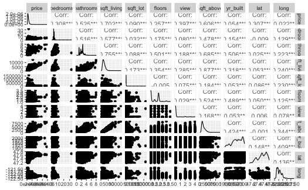

```r
houses_tidy_numeric %>%
  ggpairs(progress = F)
```

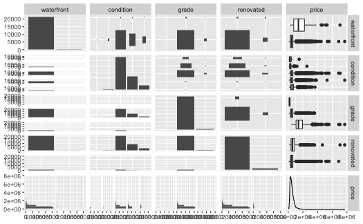

The highest correlation between numeric explanatory variables and `price` has variable `sqft_living` For non-numeric variables, the `waterfront` and `grade` seem to show some separation that might be indicating some significant association

# Model 1

## Model 1a

### R-squared: 0.4929

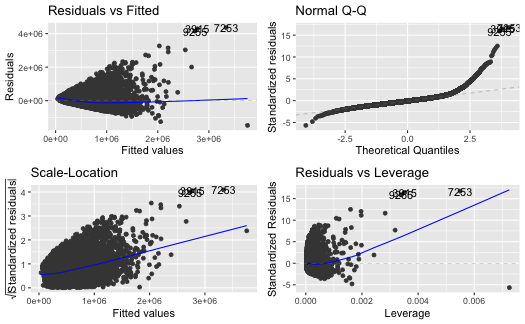

```r
# start with simple linear regression explaining house prices by sqft_living
mod1a <- lm(price ~ sqft_living, data = houses_tidy)

# diagnostic plot
autoplot(mod1a)
```

```r
# summary
summary(mod1a)
```

```
Call:
lm(formula = price ~ sqft_living, data = houses_tidy)

Residuals:
     Min       1Q   Median       3Q      Max
-1476062  -147486   -24043   106182  4362067

Coefficients:
              Estimate Std. Error t value Pr(>|t|)
(Intercept) -43580.743   4402.690  -9.899   <2e-16 ***
sqft_living    280.624      1.936 144.920   <2e-16 ***
---
Signif. codes:  0 ‘***’ 0.001 ‘**’ 0.01 ‘*’ 0.05 ‘.’ 0.1 ‘ ’ 1

Residual standard error: 261500 on 21611 degrees of freedom
Multiple R-squared:  0.4929,    Adjusted R-squared:  0.4928
F-statistic: 2.1e+04 on 1 and 21611 DF,  p-value: < 2.2e-16
```

Model 1 is fairly poor, sqft_living is a significant predictor, but the model overall explains on average just 49% of the variation in the house prices. Diagnostic plots are suggesting, there might be some issues with the assumptions on residuals.

## Model 1b

### R-squared: 0.07095

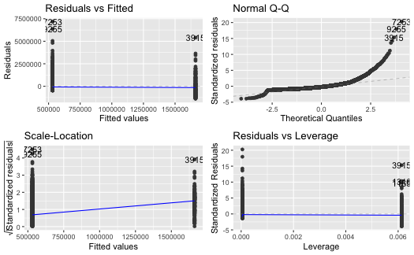

```r
# start with simple linear regression explaining house prices by sqft_living
mod1b <- lm(price ~ waterfront, data = houses_tidy)

# diagnostic plot
autoplot(mod1b)
```

```r
# summary
summary(mod1b)
```

```
Call:
lm(formula = price ~ waterfront, data = houses_tidy)

Residuals:
     Min       1Q   Median       3Q      Max
-1376876  -211564   -81564   108436  7168436

Coefficients:
               Estimate Std. Error t value Pr(>|t|)
(Intercept)      531564       2416  220.00   <2e-16 ***
waterfrontTRUE  1130312      27822   40.63   <2e-16 ***
---
Signif. codes:  0 ‘***’ 0.001 ‘**’ 0.01 ‘*’ 0.05 ‘.’ 0.1 ‘ ’ 1

Residual standard error: 353900 on 21611 degrees of freedom
Multiple R-squared:  0.07095,   Adjusted R-squared:  0.07091
F-statistic:  1650 on 1 and 21611 DF,  p-value: < 2.2e-16
```

## Model 1c

### R-squared: 0.2289

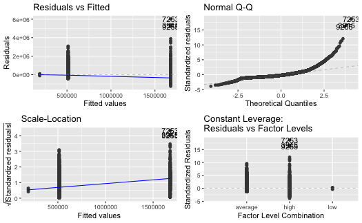

```r
# and finaly simple linear regression explaining house prices by grade category
mod1c <- lm(price ~ grade, data = houses_tidy)

# diagnostic plot
autoplot(mod1c)
```

```r
# summary
summary(mod1c)
```

```
Call:
lm(formula = price ~ grade, data = houses_tidy)

Residuals:
     Min       1Q   Median       3Q      Max
-1258635  -198076   -68576   111924  6021365

Coefficients:
             Estimate Std. Error t value Pr(>|t|)
(Intercept)    189750     161204   1.177   0.2392
gradeaverage   323326     161219   2.006   0.0449 *
gradehigh     1488885     161845   9.199   <2e-16 ***
---
Signif. codes:  0 ‘***’ 0.001 ‘**’ 0.01 ‘*’ 0.05 ‘.’ 0.1 ‘ ’ 1

Residual standard error: 322400 on 21610 degrees of freedom
Multiple R-squared:  0.2289,    Adjusted R-squared:  0.2288
F-statistic:  3207 on 2 and 21610 DF,  p-value: < 2.2e-16
```

# Model 2

so far the best model was Mod1a, we will go with that one

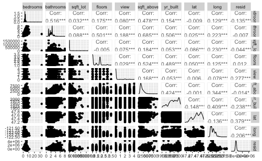

```r
# looking at remaining predictors
houses_tidy_resid <- houses_tidy %>%
  add_residuals(mod1) %>%
  select(-c("price", "sqft_living"))

# again display only for numeric variables
houses_tidy_resid %>%
  select_if(is.numeric) %>%
  ggpairs(progress = FALSE)
```

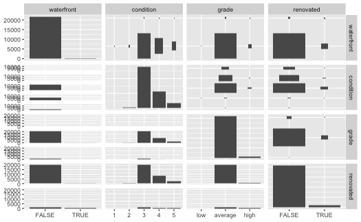

```r
# and again only for non-numeric variables
houses_tidy_resid %>%
  select_if(function(x) !is.numeric(x)) %>%
  ggpairs(progress = FALSE)
```

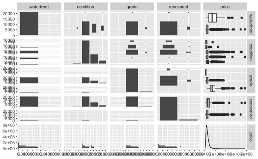

```r
# and again only for non-numeric variables
houses_tidy_resid_nonnumeric <- houses_tidy_resid %>%
  select_if(function(x) !is.numeric(x))

houses_tidy_resid_nonnumeric$price <- houses_tidy$price

houses_tidy_resid_nonnumeric %>%
  ggpairs(progress = FALSE)
```

`lat` is showing the highest correlation between remaining explanatory variables and mod1a. For non-numeric variables, again, the `waterfront` and `grade` seem to show some separation that might be indicating some significant association.

## Model 2a

### R-squared: 0.566

### Residual standard error: 241900

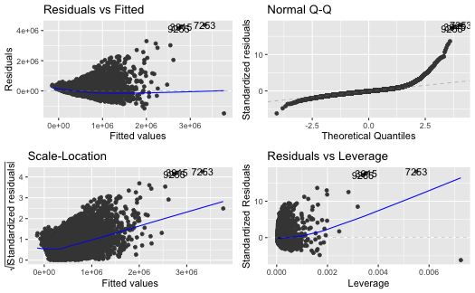

```r
mod2a <- lm(price ~ sqft_living + lat, data = houses_tidy)
autoplot(mod2a)
```

```r
summary(mod2a)
```

```
Call:
lm(formula = price ~ sqft_living + lat, data = houses_tidy)

Residuals:
     Min       1Q   Median       3Q      Max
-1487994  -125643   -20309    84613  4368717

Coefficients:
              Estimate Std. Error t value Pr(>|t|)
(Intercept) -3.416e+07  5.653e+05  -60.44   <2e-16 ***
sqft_living  2.749e+02  1.794e+00  153.27   <2e-16 ***
lat          7.177e+05  1.189e+04   60.36   <2e-16 ***
---
Signif. codes:  0 ‘***’ 0.001 ‘**’ 0.01 ‘*’ 0.05 ‘.’ 0.1 ‘ ’ 1

Residual standard error: 241900 on 21610 degrees of freedom
Multiple R-squared:  0.566, Adjusted R-squared:  0.566
F-statistic: 1.409e+04 on 2 and 21610 DF,  p-value: < 2.2e-16
```

## Model 2b

### R-squared: 0.5298

### Residual standard error: 251800

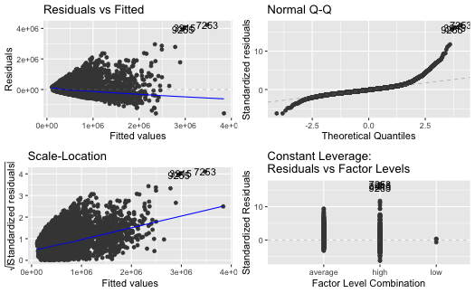

```r
mod2b <- lm(price ~ sqft_living + grade, data = houses_tidy)
autoplot(mod2b)
```

```r
summary(mod2b)
```

```
Call:
lm(formula = price ~ sqft_living + grade, data = houses_tidy)

Residuals:
     Min       1Q   Median       3Q      Max
-1563444  -142171   -24219   101170  4223486

Coefficients:
               Estimate Std. Error t value Pr(>|t|)
(Intercept)   63098.672 125883.834   0.501 0.616204
sqft_living     243.560      2.071 117.606  < 2e-16 ***
gradeaverage -41681.602 125929.407  -0.331 0.740654
gradehigh    478514.249 126671.413   3.778 0.000159 ***
---
Signif. codes:  0 ‘***’ 0.001 ‘**’ 0.01 ‘*’ 0.05 ‘.’ 0.1 ‘ ’ 1

Residual standard error: 251800 on 21609 degrees of freedom
Multiple R-squared:  0.5298,    Adjusted R-squared:  0.5297
F-statistic:  8116 on 3 and 21609 DF,  p-value: < 2.2e-16
```

mod2a explains the variance in price slightly better, let’s go with that one. We now have two models mod1a and mod2a. We need to check whether they both explain the same amount of variance -> ANOVA (ie. looking at `sqft_living` alone, or `sqft_living` and `lat`)

## ANOVA

```r
anova(mod1a, mod2a)
```

```
Analysis of Variance Table

Model 1: price ~ sqft_living
Model 2: price ~ sqft_living + lat
  Res.Df        RSS Df  Sum of Sq      F    Pr(>F)
1  21611 1.4773e+15
2  21610 1.2641e+15  1 2.1314e+14 3643.5 < 2.2e-16 ***
---
Signif. codes:  0 ‘***’ 0.001 ‘**’ 0.01 ‘*’ 0.05 ‘.’ 0.1 ‘ ’ 1
```

p-value is signifficant, model including both explanatory variables is better! We are going to include `lat`

So far, the model mod2a is the best, containing two main effects (explanatory variables `sqft_living` and `lat`)

# Model 3

## Model 3a

### R-squared: 0.6005

### Residual standard error: 232100

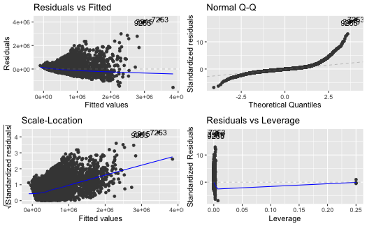

```r
# `grade` was showing some great properties as an explanatory variable, let's add it to the current best model mod2a
mod3a <- lm(price ~ sqft_living + lat + grade, data = houses_tidy)
autoplot(mod3a)
```

```r
summary(mod3a)
```

```
Call:
lm(formula = price ~ sqft_living + lat + grade, data = houses_tidy)

Residuals:
     Min       1Q   Median       3Q      Max
-1568766  -114882   -20697    74277  4234354

Coefficients:
               Estimate Std. Error t value Pr(>|t|)
(Intercept)  -3.338e+07  5.530e+05 -60.363  < 2e-16 ***
sqft_living   2.393e+02  1.910e+00 125.259  < 2e-16 ***
lat           7.059e+05  1.141e+04  61.853  < 2e-16 ***
gradeaverage -1.592e+05  1.161e+05  -1.371  0.17040
gradehigh     3.434e+05  1.168e+05   2.940  0.00328 **
---
Signif. codes:  0 ‘***’ 0.001 ‘**’ 0.01 ‘*’ 0.05 ‘.’ 0.1 ‘ ’ 1

Residual standard error: 232100 on 21608 degrees of freedom
Multiple R-squared:  0.6005,    Adjusted R-squared:  0.6005
F-statistic:  8121 on 4 and 21608 DF,  p-value: < 2.2e-16
```

```r
anova(mod2a, mod3a)
```

```
Analysis of Variance Table

Model 1: price ~ sqft_living + lat
Model 2: price ~ sqft_living + lat + grade
  Res.Df        RSS Df  Sum of Sq      F    Pr(>F)
1  21610 1.2641e+15
2  21608 1.1636e+15  2 1.0053e+14 933.45 < 2.2e-16 ***
---
Signif. codes:  0 ‘***’ 0.001 ‘**’ 0.01 ‘*’ 0.05 ‘.’ 0.1 ‘ ’ 1
```

yes, we go with mod3a!

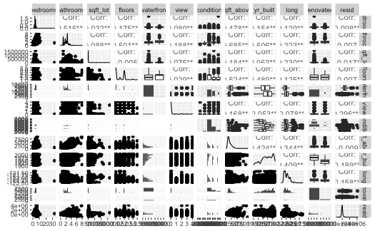

```r
# looking at all the remaining predictors
houses_tidy_resid <- houses_tidy %>%
  add_residuals(mod3a) %>%
  select(-c("price", "sqft_living", "lat", "grade"))

# again display only for numeric variables
houses_tidy_resid %>%
  ggpairs(progress = FALSE)
```

# Model 4

## Model 4a

### R-squared: 0.6388

### Residual standard error: 220700

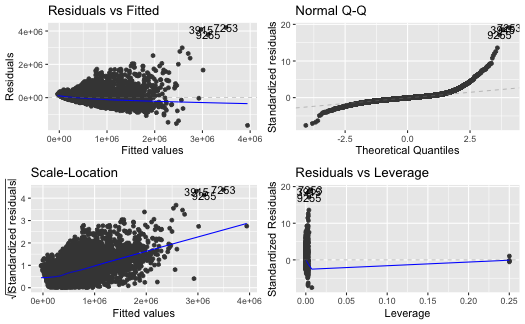

```r
# `view` has the highest correlating among remaining predictors and current model, let's add it
mod4a <- lm(price ~ sqft_living + lat + grade + view, data = houses_tidy)
autoplot(mod4a)
```

```r
summary(mod4a)
```

```
Call:
lm(formula = price ~ sqft_living + lat + grade + view, data = houses_tidy)

Residuals:
     Min       1Q   Median       3Q      Max
-1665055  -107408   -14355    74719  4205606

Coefficients:
               Estimate Std. Error t value Pr(>|t|)
(Intercept)  -3.364e+07  5.259e+05 -63.966  < 2e-16 ***
sqft_living   2.187e+02  1.867e+00 117.141  < 2e-16 ***
lat           7.116e+05  1.085e+04  65.565  < 2e-16 ***
gradeaverage -1.501e+05  1.104e+05  -1.360  0.17393
gradehigh     3.141e+05  1.111e+05   2.829  0.00468 **
view          9.801e+04  2.049e+03  47.842  < 2e-16 ***
---
Signif. codes:  0 ‘***’ 0.001 ‘**’ 0.01 ‘*’ 0.05 ‘.’ 0.1 ‘ ’ 1

Residual standard error: 220700 on 21607 degrees of freedom
Multiple R-squared:  0.6388,    Adjusted R-squared:  0.6387
F-statistic:  7643 on 5 and 21607 DF,  p-value: < 2.2e-16
```

### Conclusion: I managed to build a model using a systematical approach, that explains on average 63% of variation in house prices with residual standard error of 220700.

price ~ sqft_living + lat + grade + view